# (tentative de) Visualisation des données du climat à Rennes depuis 1999 avec R

2017-10-12

Après être tombé sur l’infographie [“Rain patterns in Hong Kong, Some of the wettest and driest days since 1990”](http://www.scmp.com/infographics/article/1243242/rain-patterns-hong-kong) du South China Morning Post, j’ai cherché à produire une visualisation similaire des données climatologiques mais appliquée à la ville de Rennes. Le code source est disponible sur [Github](https://github.com/neveldo/rstats-weather).

Des données climatologiques sont disponibles en Licence Ouverte Etalab sur **Météo-France** au travers de [bulletins climatiques mensuels](https://donneespubliques.meteofrance.fr/?fond=produit&id_produit=129&id_rubrique=52). Malheureusement, seuls des résumés mensuels (températures moyennes, cumuls de précipitation, etc) sont accessibles. Impossible d’y trouver des données quotidiennes donc (Météo-France, si vous me lisez …).

Dans le code R ci-dessous, les données ont déjà été préalablement nettoyées, structurées et stockées au sein d’un [triplestore RDF](https://fr.wikipedia.org/wiki/Triplestore) que nous pouvons donc directement interroger en **SPARQL** à l’aide du package `{SPARQL}`.

Malgré tout, on peut quand même y repérer facilement quelques “exceptions”. Par exemple, le mois de **juin 2016** a été particulièrement pauvre en insolation avec un total de seulement 90 heures. Voir par exemple l’article du Télégramme à ce sujet : [Bretagne. Mais où est passé le soleil ?](http://www.letelegramme.fr/bretagne/bretagne-mais-ou-est-passe-le-soleil-01-07-2016-11131736.php). On peut également voir que le mois de **janvier 2017** a été particulièrement froid avec une moyenne des températures minimales de -0.3°. Voir [l’article du Télégramme à ce sujet](http://www.letelegramme.fr/finistere/chateaulin/froid-jusqu-a-9-c-a-chateaulin-la-nuit-prochaine-20-01-2017-11370397.php?vptoken=754e5dd2f086459369e5c1ba833110f4e30a39e2).

**Note** : L’objectif était simplement d’avoir un prétexte pour continuer mon apprentissage de R, du format R Markdown ainsi que de certains packages par la pratique. On pourrait bien sûr améliorer la pertinence de cette mini-infographie avec des données quotidiennes, en y ajoutant de l’interactivité, par exemple en permettant à l’utilisateur de comparer les données avec celles des autres stations météo, exploiter d’autres variables, etc.

```r
endpoint <- "" # Configure your triplestore endpoint here

query <- "
SELECT ?label xsd:string(?date) as ?date ?hrr ?ins ?tn ?tx WHERE {
  ?weatherReport a weather:Report ;
    weather:linkedToStation ?station ;
    weather:reportDate ?date ;
    weather:hrrMm ?hrr ;
    weather:instH ?ins ;
    weather:tnC ?tn ;
    weather:txC ?tx .
  ?station rdfs:label 'Rennes' ;
    rdfs:label ?label .
}
"

results <- SPARQL(endpoint, query)$results %>%
  as.tibble() %>%
  mutate(
    year = factor(year(date)),
    month = factor(month(date), labels = c("janvier", "février", "mars", "avril", "mai", "juin", "juillet", "août", "septembre", "octobre", "novembre", "décembre"))
  )
```

Contenu de results

| label | date | hrr | ins | tn | tx | year | month |
| --- | --- | --- | --- | --- | --- | --- | --- |
| Rennes | 1999-01-01 | 88.6 | 72 | 4.9 | 10.5 | 1999 | janvier |
| Rennes | 1999-02-01 | 56.4 | 60 | 3.9 | 9.7 | 1999 | février |
| Rennes | 1999-03-01 | 52.4 | 117 | 5.7 | 13.5 | 1999 | mars |
| Rennes | 1999-04-01 | 98.4 | 121 | 7.8 | 15.3 | 1999 | avril |
| Rennes | 1999-05-01 | 56.8 | 166 | 11.1 | 20.8 | 1999 | mai |

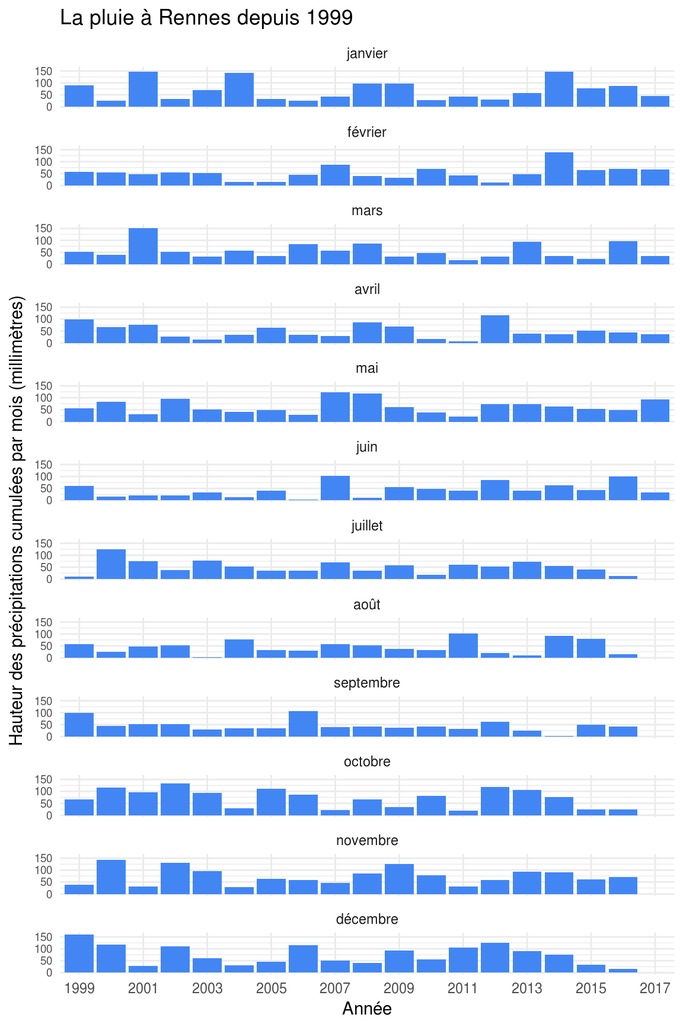

```r
results %>%
  ggplot(aes(x = year, y = hrr, group = 1)) +
  geom_col(fill = "#4286f4") +
  labs(
    title = "La pluie à Rennes depuis 1999",
    x = "Année",
    y = "Hauteur des précipitations cumulées par mois (millimètres)"
  ) +
  facet_wrap(~month, ncol = 1) +
  scale_x_discrete(breaks=seq(1999, 2017, 2)) +
  theme_minimal() +
  theme(axis.text.y = element_text(size = rel(0.8)))
```

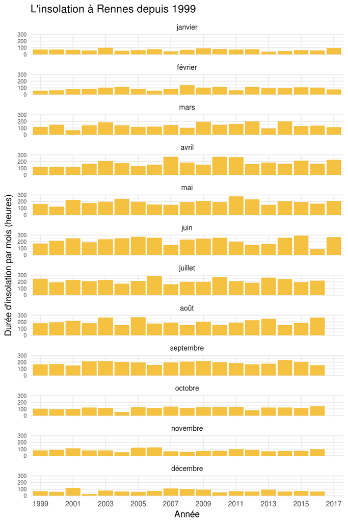

```r
results %>%
  ggplot(aes(x = year, y = ins, group = 1)) +
  geom_col(fill = "#f4c141") +
  labs(
    title = "L'insolation à Rennes depuis 1999",
    x = "Année",
    y = "Durée d'insolation par mois (heures)"
  ) +
  facet_wrap(~month, ncol = 1) +
  scale_x_discrete(breaks=seq(1999, 2017, 2)) +
  theme_minimal() +
  theme(axis.text.y = element_text(size = rel(0.8)))
```

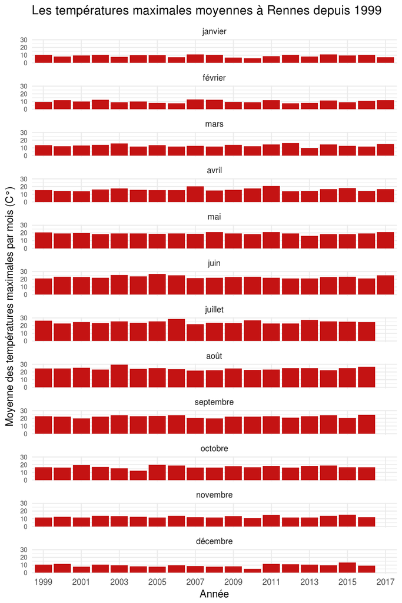

```r
results %>%
  ggplot(aes(x = year, y = tx, group = 1)) +
  geom_col(fill = "#c41313") +
  labs(
    title = "Les températures maximales moyennes à Rennes depuis 1999",
    x = "Année",
    y = "Moyenne des températures maximales par mois (C°)"
  ) +
  facet_wrap(~month, ncol = 1) +
  scale_x_discrete(breaks=seq(1999, 2017, 2)) +
  theme_minimal() +
  theme(axis.text.y = element_text(size = rel(0.8)))
```

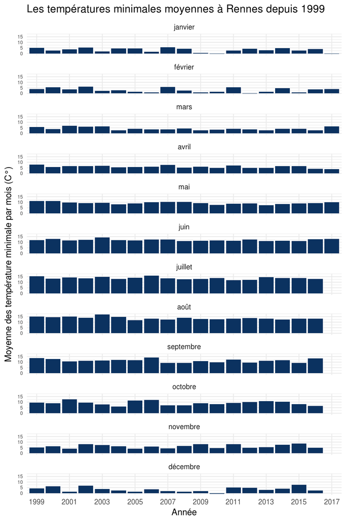

```r
results %>%
  ggplot(aes(x = year, y = tn, group = 1)) +
  geom_col(fill = "#0b3260") +
  labs(
    title = "Les températures minimales moyennes à Rennes depuis 1999",
    x = "Année",
    y = "Moyenne des température minimale par mois (C°)"
  ) +
  facet_wrap(~month, ncol = 1) +
  scale_x_discrete(breaks=seq(1999, 2017, 2)) +
  theme_minimal() +
  theme(axis.text.y = element_text(size = rel(0.7)))
```